Dupilumab cohort · respiration → HRV · 2 September 2026

# Depth Gain & Smell Recovery

Patients whose sense of smell improved most over the first month of treatment also showed the largest increase in how strongly a deeper breath drives their heart rate. The effect is specific to respiratory–cardiac coupling, absent from general heart-rate variability, and does not survive multiplicity correction at this sample size.

Primary correlation

+0.79

Δ depth gain vs Δ olfaction, session 1→2, n = 7 subjects

Family-corrected

0.159

Max-statistic permutation across 7 metrics — not significant

Sessions analysed

25

Of 29 breathing finals; 13 change intervals from 9 subjects

Duration-slope null

+0.69

Mean artifact in the original estimand. Depth-slope null: ≈ 0

## What was asked, and what changed

The question was whether the respiration → HRV transfer function steepens across sessions, and whether that steepening tracks olfactory recovery. The honest answer required first replacing the estimand, because the original one could not have answered it.

The original slope was measuring an artifact

Regressing within-breath heart-period range on breath **duration** has a built-in positive slope that has nothing to do with physiology: a longer breath is a longer window, a longer window contains more heartbeats, and the range of more samples is simply larger. Across the 25 sessions the surrogate null for the duration slope ran +0.44 to +1.03 — the same size as the raw effect being measured.

Breath depth has no such artifact

Depth does not set the length of the analysis window, so the order-statistics effect does not apply. Measured directly: the depth-slope null across all 25 sessions falls between −0.011 and +0.022 — indistinguishable from zero. The depth slope (θ<sub>depth</sub>) is therefore the well-posed version of the question: **how much cardiac modulation does a deeper breath recruit?**

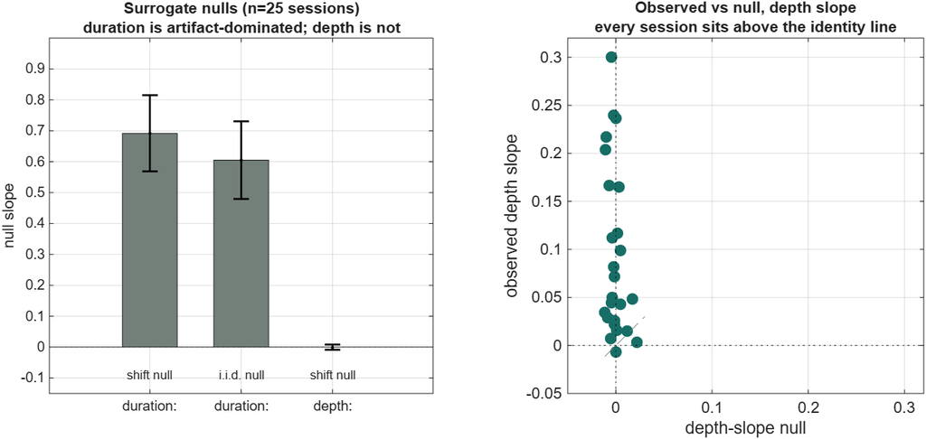

## The primary result

The pre-specified contrast is session 1 → 2, the interval every subject shares and which is tightly matched at 28–42 days. Seven subjects have it: AB, DB, GH, JH, JL, KS and PC.

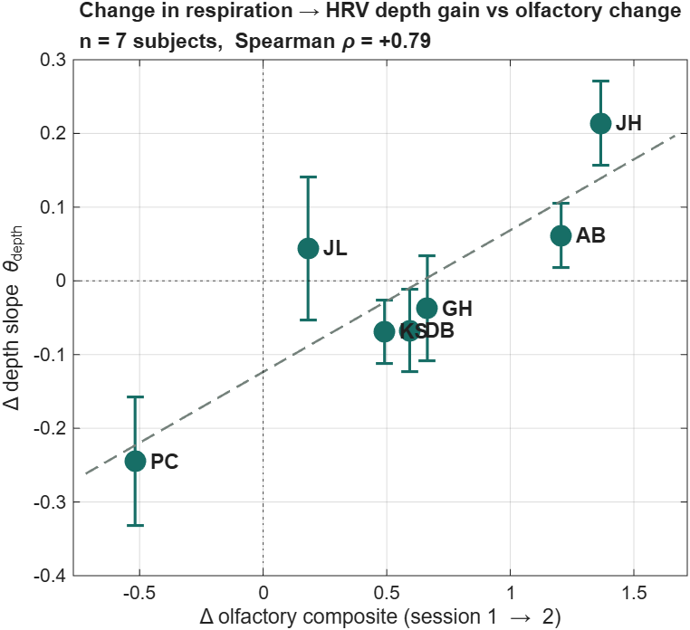

**Δ depth gain vs Δ olfaction, session 1→2.** Spearman ρ = +0.79. PC, the one subject whose olfaction declined, is also the one whose depth gain fell most. JH, who improved most, gained most. Error bars are surrogate-derived standard errors on each subject's change.

P(ρ>0) is the fraction of 20,000 draws in which the rank correlation stays positive when each subject's change score is perturbed by its own standard error. n = 7 for the depth slopes, n = 6 for panel metrics (JL failed the beat-quality gate).

| Measure | What it is | ρ | Jackknife range | P(ρ>0) |
| --- | --- | --- | --- | --- |
| adjLogRSA | RSA level at a fixed reference breath | +0.886 | +0.80 to +0.90 | 0.992 |
| thetaVol | Depth slope, surrogate-corrected | +0.786 | +0.66 to +1.00 | 1.000 |
| logMedPV | Median peak-valley RSA per breath | +0.771 | +0.60 to +0.90 | 0.999 |
| b_vol | Depth slope, uncorrected | +0.750 | +0.60 to +0.94 | 0.999 |
| logRMSSD | Beat-to-beat variability | +0.486 | +0.10 to +0.80 | 0.989 |
| logMASD | Outlier-robust beat-to-beat variability | −0.257 | −0.60 to +0.10 | 0.203 |
| pNN20 | Proportion of successive differences > 20 ms | −0.257 | −0.60 to +0.10 | 0.123 |

## The pattern is construct-specific

This is the part that makes the result more than a lucky ordering. The metrics do not scatter randomly around zero: they split cleanly along a physiological line.

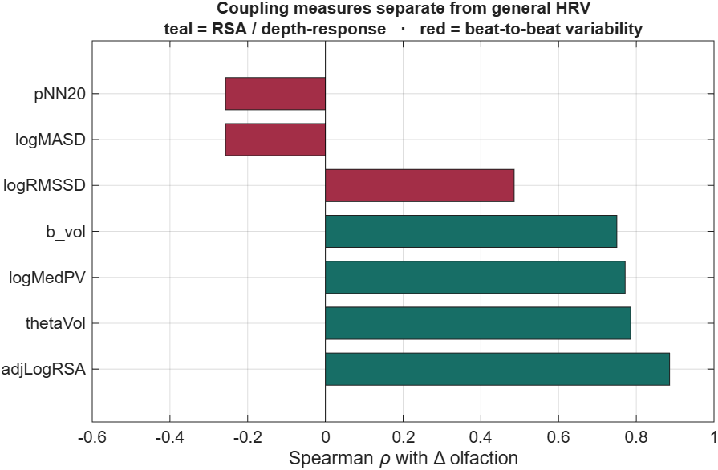

**Four coupling measures positive, three general-HRV measures not.** Everything that indexes respiratory–cardiac coupling — RSA level, depth response, peak-valley RSA — lands between +0.75 and +0.89. Everything that indexes generic beat-to-beat variability lands between −0.26 and +0.49.

If this were noise, the seven metrics would not partition by construct. The interpretation it supports is narrow and specific: what tracks olfactory recovery is **how strongly respiration drives the heart**, not how variable the heart is overall. That is a coupling story, not a vagal-tone story, and it is a more constrained claim than the one we set out to test.

Two confound checks came back clean. Change in mean heart rate correlates with olfactory change at ρ = −0.21, and change in breathing rate at ρ = +0.09 — both far below the effect, so neither the heart-rate mechanism nor a breathing-rate shift explains it.

## What does not hold

Three things temper this, and they belong in the same breath as the result.

### It is not significant after multiplicity correction

Screening seven metrics against one outcome inflates the best one. The honest inferential device is a max-statistic permutation that shuffles subject labels and records the largest |ρ| anywhere in the family. Observed max is 0.886; the permutation p is **0.159**. With 5,040 orderings the resolution floor is 0.0002, so this is a real failure to reach significance, not a resolution limit.

### It weakens when the six-month intervals are pooled in

Across all 13 adjacent intervals the depth-slope correlation attenuates to +0.335 and the beat-to-beat measures turn negative. The max statistic falls to 0.335 with a permutation **p = 0.729** over 362,880 orderings — no signal at all once the intervals are pooled. The heart-rate confound also grows, from ρ = −0.21 in the primary contrast to **+0.39** here, so the pooled analysis is both weaker and less clean.

The session 2 → 3 intervals span ~140 days rather than ~31, and four of six subjects *lose* olfactory ground over them. Whether that reflects waning response, variable adherence, or something procedural is a question for you — session means show no systematic artifact (composite −0.51, +0.28, +0.26 for sessions 1/2/3), so it looks like genuine heterogeneity in trajectory rather than a measurement problem.

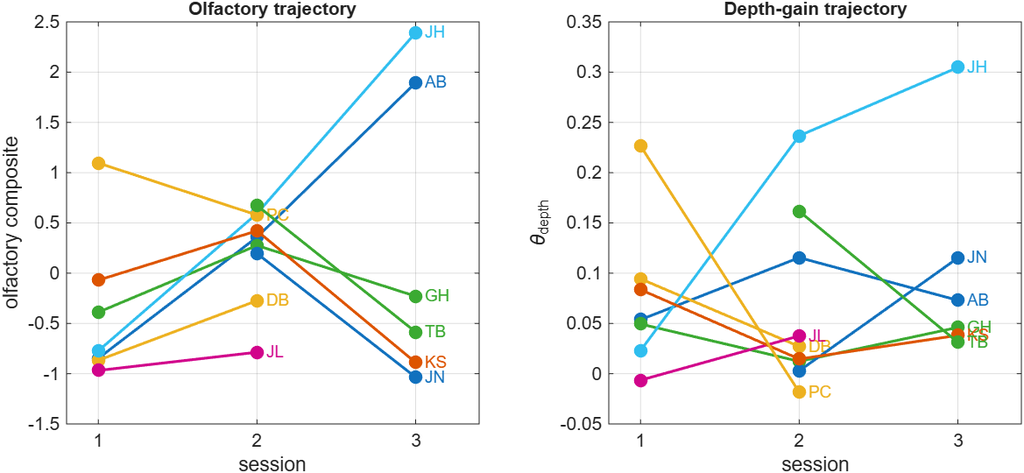

**Trajectories diverge after the first month.** JH and AB keep improving through six months; GH, JN, KS and TB peak at one month and fall back. Pooling a 31-day change with a 140-day change assumes a linearity these trajectories do not support.

## Reliability gate

Before any outcome was touched, every candidate metric was screened on κ = mean SE² / var(Δ), which asks whether the between-subject spread exceeds the measurement noise. Metrics failing κ ≤ 0.5 were dropped without ever being correlated with olfaction. This is what the previous round of this analysis failed outright, when the duration slope came in at κ ≈ 1.

The duration slope fails its own reliability gate. The depth slope passes comfortably.

| Metric | var(Δ) | mean SE | κ | Verdict |
| --- | --- | --- | --- | --- |
| pNN20 | 108.63 | 3.202 | 0.10 | retain |
| logMASD | 0.0706 | 0.092 | 0.13 | retain |
| logMedPV | 0.0616 | 0.105 | 0.19 | retain |
| logRMSSD | 0.0468 | 0.096 | 0.22 | retain |
| thetaVol | 0.0201 | 0.065 | 0.23 | retain |
| b_vol | 0.0179 | 0.065 | 0.26 | retain |
| adjLogRSA | 0.0440 | 0.113 | 0.30 | retain |
| b_len | 0.3284 | 0.423 | 0.60 | drop |
| theta (duration) | 0.1837 | 0.423 | 1.08 | drop |
| depthSlope (panel) | 0.0862 | 0.305 | 1.14 | drop |
| logHF | 0.0692 | 0.398 | 2.46 | drop |
| evokedRSA | 0.0000 | 0.009 | 3.09 | drop |

## Data problems found

Metadata gap — cost 11 sessions on the first pass

The `noseMouth` field is empty for 31–46% of breaths in 11 sessions, concentrated in the `audio` and `focus` blocks. No session anywhere carries an explicit `"mouth"`; values are `"nose"`, `"NA"` or empty. Since respiration is recorded with a nasal cannula, a detected breath with a valid RSA value was necessarily nasal, so empty means unrecorded metadata. Filtering on `== "nose"` silently discarded most of the newly preprocessed data and collapsed those sessions to a single block. Worth populating the field, or documenting that empty means nose.

Corrupt file

250811_Dupi_NMH_TB_2_PEA_threshold_preproc.mat fails to open with an HDF5 `inflate()` error. It has now failed on two attempts four days apart, so this is genuine corruption rather than a network read failure. TB_2 has no threshold component until it is rebuilt.

Beat quality

JL_1 rejects 42% of its NN intervals and fails the beat-quality gate. PD_1, JA_1 and JA_2 yield only 52–59 spontaneous breaths against a 60-breath minimum, so they contribute to the slope analysis but not the vagal panel. An ectopic filter was added this round after the previous one — which only checked each interval against a local median — let through short-long ectopic pairs that inflated RMSSD six-fold in one session and manufactured a spurious perfect correlation.